# Homework3

Brandon

May 21, 2018

# Questions 1: GitHub Cloning (20 points): Using Git, clone the following GitHub repository to your local machine: https://github.com/caesar0301/awesome-public-datasets. In RMarkdown, please show the ccaode (commented out, as it’s not R syntax) that you used to create a new directory, navigate to the appropriate directory, and clone the repository to it. Like actual Git, one command per line/, please.

brndn@LAPTOP-TFJDQUU9 MINGW64 ~ $ cd OneDrive

brndn@LAPTOP-TFJDQUU9 MINGW64 ~/OneDrive $ ls desktop.ini ‘Getting started with OneDrive.pdf’ Documents/ Pictures/ ‘Email attachments’/ ‘PwC_Intercompany_Assessment_for_061217 v18c.pptx’

brndn@LAPTOP-TFJDQUU9 MINGW64 ~/OneDrive $ cd Documents

brndn@LAPTOP-TFJDQUU9 MINGW64 ~/OneDrive/Documents $ ls 42D81330 ‘Height (4).csv’ R/ ‘bridge to stat’/ Hello_txt.txt SASUniversityEdition/ ‘computer receipt.jpg’ ‘Intro Python and R’/ ‘Semester 1 Courses’/ ‘Custom Office Templates’/ ‘My Kindle Content’/ testdir/ desktop.ini ‘My SAS Files’/ ‘uranium (1).csv’ ggplot2/ ‘Programming Files’/ GitHub/ ‘Python Scripts’/

brndn@LAPTOP-TFJDQUU9 MINGW64 ~/OneDrive/Documents $ cd Github

brndn@LAPTOP-TFJDQUU9 MINGW64 ~/OneDrive/Documents/Github (master) $ ls 6306Homework3/ Homework3/ PythonIntroBridge/

brndn@LAPTOP-TFJDQUU9 MINGW64 ~/OneDrive/Documents/Github (master) $ cd Homework3

brndn@LAPTOP-TFJDQUU9 MINGW64 ~/OneDrive/Documents/Github/Homework3 (master) $ ls

brndn@LAPTOP-TFJDQUU9 MINGW64 ~/OneDrive/Documents/Github/Homework3 (master) $ github https://github.com/caesar0301/awesome-public-datasets.git

brndn@LAPTOP-TFJDQUU9 MINGW64 ~/OneDrive/Documents/Github/Homework3 (master) $ cd awesome-public-datasets bash: cd: awesome-public-datasets: No such file or directory

brndn@LAPTOP-TFJDQUU9 MINGW64 ~/OneDrive/Documents/Github/Homework3 (master) $ ^C

brndn@LAPTOP-TFJDQUU9 MINGW64 ~/OneDrive/Documents/Github/Homework3 (master) $ git clone https://github.com/caesar0301/awesome-public-datasets.git Cloning into ‘awesome-public-datasets’… remote: Counting objects: 1475, done. remote: Compressing objects: 100% (18/18), done. remote: Total 1475 (delta 26), reused 40 (delta 24), pack-reused 1433 Receiving objects: 100% (1475/1475), 544.54 KiB | 641.00 KiB/s, done. Resolving deltas: 100% (859/859), done.

brndn@LAPTOP-TFJDQUU9 MINGW64 ~/OneDrive/Documents/Github/Homework3 (master) $ ls __MACOSX/ awesome-public-datasets/ titanic.csv

brndn@LAPTOP-TFJDQUU9 MINGW64 ~/OneDrive/Documents/Github/Homework3 (master) $ cd awesome-public-datasets/

brndn@LAPTOP-TFJDQUU9 MINGW64 ~/OneDrive/Documents/Github/Homework3/awesome-public-datasets (master) $ ls Datasets/ LICENSE README.rst

brndn@LAPTOP-TFJDQUU9 MINGW64 ~/OneDrive/Documents/Github/Homework3/awesome-public-datasets (master) $ cd Datasets

brndn@LAPTOP-TFJDQUU9 MINGW64 ~/OneDrive/Documents/Github/Homework3/awesome-public-datasets/Datasets (master) $ ls titanic.csv.zip

brndn@LAPTOP-TFJDQUU9 MINGW64 ~/OneDrive/Documents/Github/Homework3/awesome-public-datasets/Datasets (master) $

# 2. Data Summary (20 points): From this aforementioned cloned repo, please extract titanic.csv.zip. To be clear, this does not have to be done in Git or command line.

## a. In R, please read in titanic.csv via either read.table() or read.csv(), assigning it to df. This dataset follows the passengers aboard the Titanic, including their fees paid, rooms rented, and survivorship status.

## b. Output the respective count of females and males aboard the Titanic. Plot the frequency of females and males. Be sure to give an accurate title and label the axes.

## c. Please use one apply function (to review: swirl() modules 11, 12) to output the means of Age, Fare, and Survival. Make sure the output is a real number for all three means.

```r
getwd()
```

```
## [1] "C:/Users/brndn/OneDrive/Documents/Semester 1 Courses/Data Science/homework/Week 3_questions"
```

```r
setwd("C:/Users/brndn/OneDrive/Documents/GitHub/Homework3")
titanic <- read.csv(file = "titanic.csv", header = TRUE, sep = ",")
table(titanic$Sex)
```

```
##
## female   male
##    314    577
```

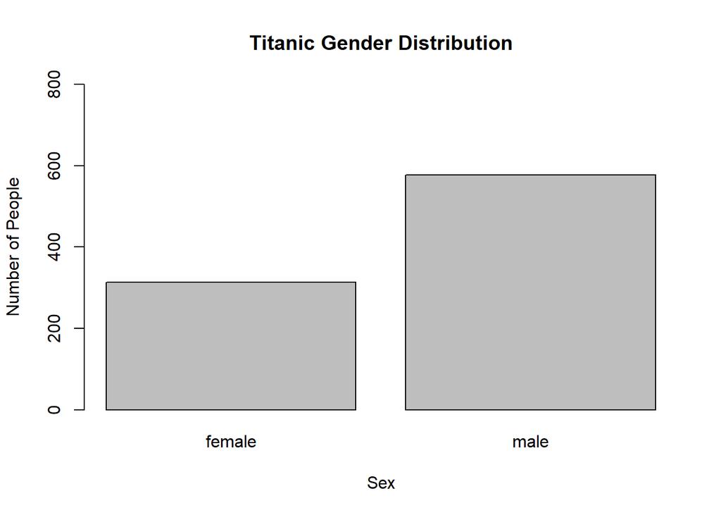

```r
barplot(table(titanic$Sex), ylim=c(0,800),main = "Titanic Gender Distribution", ylab = "Number of People", xlab = "Sex")
```

```r
apply(titanic[,c("Survived", "Age", "Fare")],2, mean, na.rm=TRUE)
```

```
##   Survived        Age       Fare
##  0.3838384 29.6991176 32.2042080
```

# 3. Function Building (30 points): You research sleep and just got your first data set. Later, you’ll have another dataset with the same column names, so you want to create a helper function that you can analyze this dataset and the next. Load sleep_data_01.csv (found at http://talklab.psy.gla.ac.uk/L1_labs/lab_1/homework/index.html). Questions 3A through 3D should be answered in function(x){}. 3E can be outside of the function.

```r
getwd()
```

```
## [1] "C:/Users/brndn/OneDrive/Documents/Semester 1 Courses/Data Science/homework/Week 3_questions"
```

```r
setwd("C:/Users/brndn/OneDrive/Documents/GitHub/Homework3")
sleep <- read.csv(file = "sleep_data_01.csv", header = TRUE, sep = ",")
```

## c. Change the column names of this data.frame to MedianAge, SelfEsteem, SE_SD, and DurationRange.

## d. Round the report to at most 2 digits: leave this as the closing line to the function.

## e. Finally, run the function on your sleep data to show the output.

```r
myfunction <- function(x) {

  MedianAge = median(x$Age,na.rm=TRUE)
  DurationMax = max(x$Duration, na.rm=TRUE)
  DurationMin = min(x$Duration, na.rm=TRUE)
  DurationRange = DurationMax - DurationMin
  RSESMean = mean(x$RSES, na.rm=TRUE)
  RSESStdev = sd(x$RSES, na.rm = TRUE)
  Report <- data.frame(MedianAge/5,RSESMean/5,RSESStdev/5,DurationRange)
  names(Report)[1] <- paste("MedianAge")
  names(Report)[2] <- paste("SelfEsteem")
  names(Report)[3] <- paste("SE_SD")
  names(Report)[4] <- paste("DurationRange")
  Report = round(Report,2)
  return(Report)

}
myfunction(sleep)
```

```
##   MedianAge SelfEsteem SE_SD DurationRange
## 1       2.8       3.62  1.24             7
```